# Assignment 6

```python
def create_model(activation='relu'):
    model = Sequential()
    model.add(Dense(50, input_dim=300, kernel_initializer='lecun_uniform', activation=activation))
    model.add(Dense(50, kernel_initializer='lecun_uniform', activation='relu'))
    model.add(Dense(1, kernel_initializer='lecun_uniform', activation='sigmoid'))
    model.compile(loss='binary_crossentropy', optimizer='adam', metrics=['accuracy'])
    return model

X = sequence.drop(['Class', 'Seq'], 1)
Y = sequence.Class
batch      = 10
epochs     = 100
activation = 'relu'

model = create_model(activation='relu')
model_fit4 = model.fit(X, Y, epochs=epochs, batch_size=batch, verbose=0, validation_split=0.15)
fits.push(model_fit4)
```

[output not shown]

[figure not shown]

[output not shown]

[figure not shown]

[output not shown]

[figure not shown]

```
<keras.optimizers.Adam object at 0x1a405a9450>
Batch Size: 10, Epochs: 100
_________________________________________________________________
Layer (type)                 Output Shape              Param #
=================================================================
dense_250 (Dense)            (None, 50)                15050
_________________________________________________________________
dense_251 (Dense)            (None, 50)                2550
_________________________________________________________________
dense_252 (Dense)            (None, 1)                 51
=================================================================
Total params: 17,651
Trainable params: 17,651
Non-trainable params: 0
_________________________________________________________________
None
```

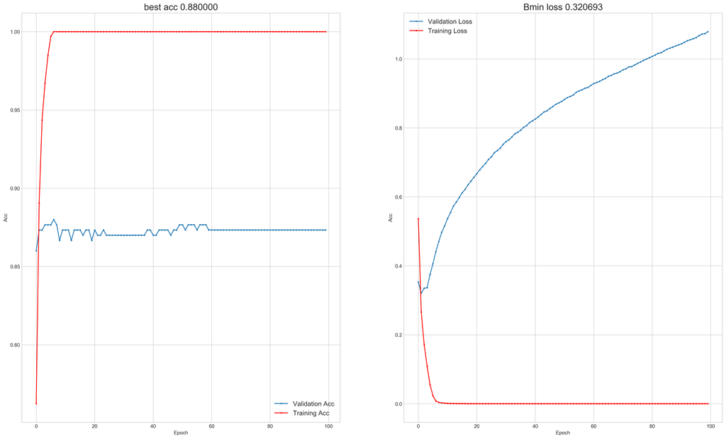

```
<keras.optimizers.Adam object at 0x1ab16a4850>
Batch Size: 10, Epochs: 100
_________________________________________________________________
Layer (type)                 Output Shape              Param #
=================================================================
dense_469 (Dense)            (None, 50)                15050
_________________________________________________________________
dense_470 (Dense)            (None, 50)                2550
_________________________________________________________________
dense_471 (Dense)            (None, 1)                 51
=================================================================
Total params: 17,651
Trainable params: 17,651
Non-trainable params: 0
_________________________________________________________________
None
```

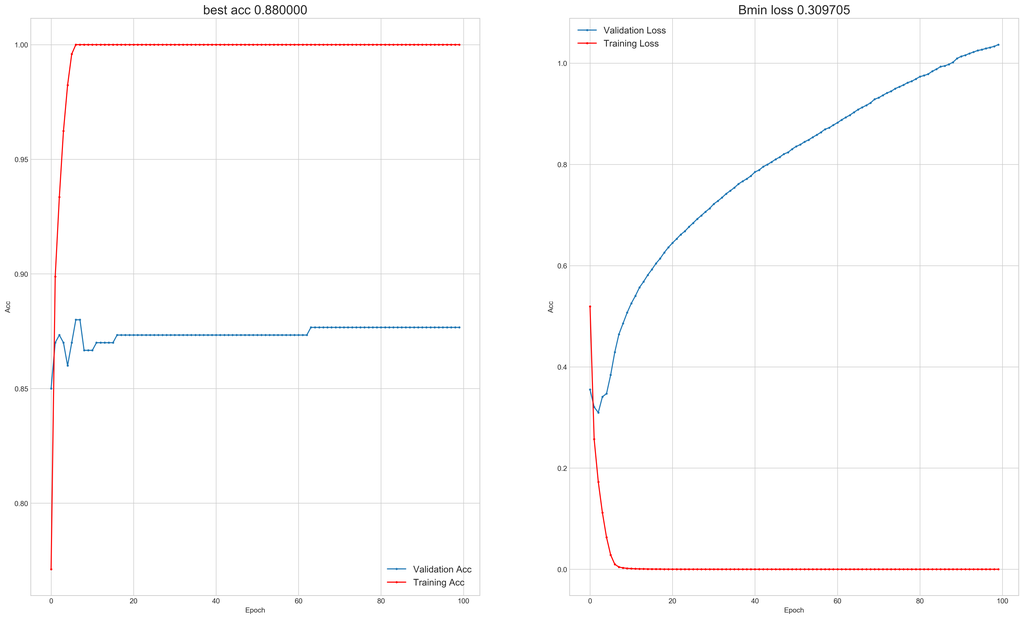

```
<keras.optimizers.Adam object at 0x1a9730e390>
Batch Size: 100, Epochs: 100
_________________________________________________________________
Layer (type)                 Output Shape              Param #
=================================================================
dense_472 (Dense)            (None, 50)                15050
_________________________________________________________________
dense_473 (Dense)            (None, 1)                 51
=================================================================
Total params: 15,101
Trainable params: 15,101
Non-trainable params: 0
_________________________________________________________________
None
```

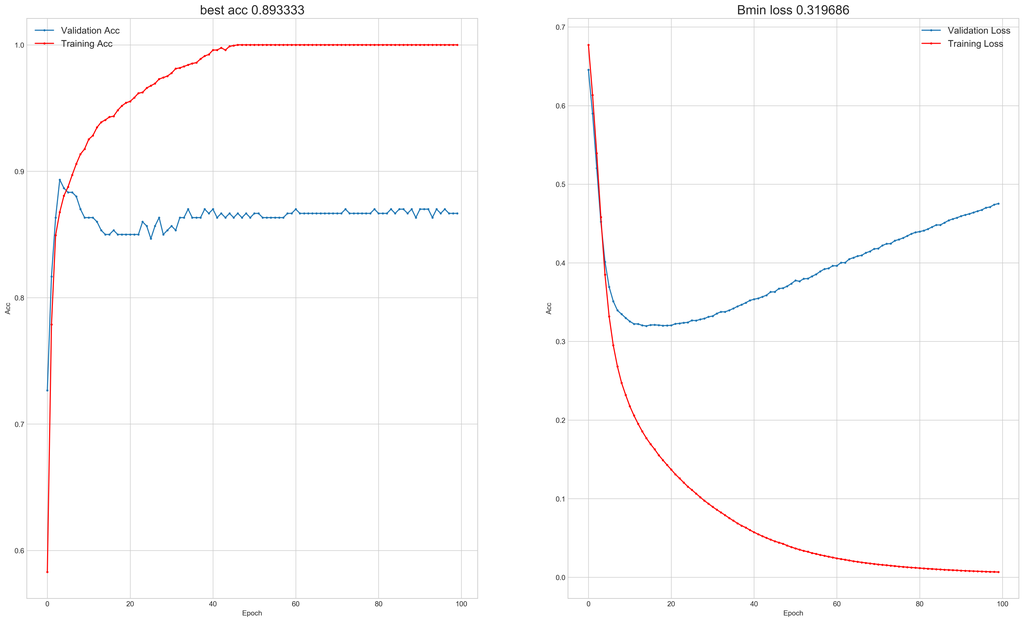

```python
def plot_hyperparams(fits):
    plt.clf()
    plt.rcParams['figure.figsize'] = (25,15)
    f, axes = plt.subplots(1, 2)
    axes = axes.ravel()
    f.set_dpi(300)
    ind = 0

    validation_accuracy = fit.history['val_acc']
    training_accuracy = fit.history['acc']
    plot(validation_accuracy, 'Validation Acc', training_accuracy, 'Training Acc',
         "best acc %f" % (max(validation_accuracy)), axes[0])

    validation_loss = fit.history['val_loss']
    training_loss = fit.history['loss']
    plot(validation_loss, 'Validation Loss', training_loss, 'Training Loss',
         "Bmin loss %f" % (min(validation_loss)), axes[1])

    f.subplots_adjust(hspace=0.4)
    plt.show()

for fit in fits:
    print fit.model.optimizer
    print 'Batch Size: %d, Epochs: %d' % (fit.params['batch_size'], fit.params['epochs'])
    print fit.model.summary()
    plot_hyperparams(fit)
```

The last model performed the best resulting in the best accuracy and the lowest loss trend. It's surprising because it's a very simple model with 1 hidden layer with 50 neurons. However, when we did the feature importance last assignment using randomforests on this dataset, there were only few columns that were very important in deciding the class, so maybe the net figured this out and that's why only 50 neurons were enough in yielding the best results.

```python
test = loaddata('Sequences_test_unlabeled.csv', ['Seq'])
test = one_hot_encoding(test)
```

```python
best_model = fits[-1].model

X = test.drop(['Seq'], 1)
predictions = best_model.predict(X)
predictions = [-1 if p < 0.5 else 1 for p in predictions]
np.savetxt('labels.txt', predictions, delimiter='\n', fmt='%1d')
```